# Mapping poverty in Texas

```r
library(tidyverse)
library(tidycensus)
library(janitor)
library(tigris)
library(waffle)
```

```r
poverty <-read_csv("data-raw/ACSST5Y2017.S1701_data_with_overlays_2019-04-27T004427.csv", skip = 1) %>% clean_names()
poverty
```

| id | geographic_area_name | estimate_total_population_for_whom_poverty_status_is_determined | margin_of_error_total_moe_population_for_whom_poverty_status_is_determined | estimate_below_poverty_level_population_for_whom_poverty_status_is_determined | margin_of_error_below_poverty_level_moe_population_for_whom_poverty_status_is_determined | estimate_percent_below_poverty_level_population_for_whom_poverty_status_is_determined | margin_of_error_percent_below_poverty_level_moe_population_for_whom_poverty_status_is_determined | estimate_total_population_for_whom_poverty_status_is_determined_age_under_18_years | margin_of_error_total_moe_population_for_whom_poverty_status_is_determined_age_under_18_years | estimate_below_poverty_level_population_for_whom_poverty_status_is_determined_age_under_18_years | margin_of_error_below_poverty_level_moe_population_for_whom_poverty_status_is_determined_age_under_18_years | estimate_percent_below_poverty_level_population_for_whom_poverty_status_is_determined_age_under_18_years | margin_of_error_percent_below_poverty_level_moe_population_for_whom_poverty_status_is_determined_age_under_18_years | estimate_total_population_for_whom_poverty_status_is_determined_age_under_18_years_under_5_years | margin_of_error_total_moe_population_for_whom_poverty_status_is_determined_age_under_18_years_under_5_years | estimate_below_poverty_level_population_for_whom_poverty_status_is_determined_age_under_18_years_under_5_years | margin_of_error_below_poverty_level_moe_population_for_whom_poverty_status_is_determined_age_under_18_years_under_5_years | estimate_percent_below_poverty_level_population_for_whom_poverty_status_is_determined_age_under_18_years_under_5_years | margin_of_error_percent_below_poverty_level_moe_population_for_whom_poverty_status_is_determined_age_under_18_years_under_5_years | estimate_total_population_for_whom_poverty_status_is_determined_age_under_18_years_5_to_17_years | margin_of_error_total_moe_population_for_whom_poverty_status_is_determined_age_under_18_years_5_to_17_years | estimate_below_poverty_level_population_for_whom_poverty_status_is_determined_age_under_18_years_5_to_17_years | margin_of_error_below_poverty_level_moe_population_for_whom_poverty_status_is_determined_age_under_18_years_5_to_17_years | estimate_percent_below_poverty_level_population_for_whom_poverty_status_is_determined_age_under_18_years_5_to_17_years | margin_of_error_percent_below_poverty_level_moe_population_for_whom_poverty_status_is_determined_age_under_18_years_5_to_17_years | estimate_total_population_for_whom_poverty_status_is_determined_age_under_18_years_related_children_of_householder_under_18_years | margin_of_error_total_moe_population_for_whom_poverty_status_is_determined_age_under_18_years_related_children_of_householder_under_18_years | estimate_below_poverty_level_population_for_whom_poverty_status_is_determined_age_under_18_years_related_children_of_householder_under_18_years | margin_of_error_below_poverty_level_moe_population_for_whom_poverty_status_is_determined_age_under_18_years_related_children_of_householder_under_18_years | … |
| --- | --- | --- | --- | --- | --- | --- | --- | --- | --- | --- | --- | --- | --- | --- | --- | --- | --- | --- | --- | --- | --- | --- | --- | --- | --- | --- | --- | --- | --- | --- |
| 0500000US48097 | Cooke County, Texas | 38242 | 241 | 5313 | 814 | 13.9 | 2.1 | 9062 | 119 | 2237 | 364 | 24.7 | 4.0 | 2535 | 82 | 770 | 170 | 30.4 | 6.8 | 6527 | 81 | 1467 | 254 | 22.5 | 3.9 | 9014 | 141 | 2189 | 362 | … |
| 0500000US48107 | Crosby County, Texas | 5809 | 51 | 1209 | 206 | 20.8 | 3.5 | 1620 | 13 | 481 | 113 | 29.7 | 7.0 | 416 | 18 | 139 | 47 | 33.4 | 10.7 | 1204 | 21 | 342 | 93 | 28.4 | 7.8 | 1612 | 16 | 473 | 113 | … |
| 0500000US48115 | Dawson County, Texas | 11235 | 226 | 2078 | 463 | 18.5 | 4.1 | 3149 | 140 | 641 | 249 | 20.4 | 8.0 | 902 | 8 | 140 | 85 | 15.5 | 9.5 | 2247 | 139 | 501 | 203 | 22.3 | 9.1 | 3123 | 166 | 615 | 248 | … |
| 0500000US48151 | Fisher County, Texas | 3835 | 31 | 666 | 142 | 17.4 | 3.7 | 787 | 89 | 193 | 75 | 24.5 | 8.3 | 236 | 61 | 55 | 33 | 23.3 | 12.4 | 551 | 95 | 138 | 65 | 25.0 | 10.1 | 779 | 91 | 185 | 77 | … |
| 0500000US48131 | Duval County, Texas | 10827 | 191 | 2731 | 495 | 25.2 | 4.6 | 2770 | 171 | 1002 | 244 | 36.2 | 8.9 | 763 | 34 | 356 | 123 | 46.7 | 15.7 | 2007 | 149 | 646 | 189 | 32.2 | 9.8 | 2770 | 171 | 1002 | 244 | … |
| 0500000US48051 | Burleson County, Texas | 17294 | 152 | 2620 | 554 | 15.1 | 3.2 | 3875 | 110 | 1044 | 297 | 26.9 | 7.8 | 1008 | 91 | 487 | 178 | 48.3 | 17.3 | 2867 | 137 | 557 | 195 | 19.4 | 6.6 | 3863 | 114 | 1032 | 297 | … |
| 0500000US48031 | Blanco County, Texas | 10915 | 127 | 1180 | 350 | 10.8 | 3.2 | 2001 | 74 | 322 | 148 | 16.1 | 7.4 | 455 | 4 | 134 | 94 | 29.5 | 20.6 | 1546 | 74 | 188 | 111 | 12.2 | 7.2 | 2001 | 74 | 322 | 148 | … |
| 0500000US48241 | Jasper County, Texas | 34339 | 231 | 5772 | 817 | 16.8 | 2.4 | 8429 | 126 | 1878 | 452 | 22.3 | 5.3 | 1972 | 123 | 527 | 212 | 26.7 | 10.8 | 6457 | 120 | 1351 | 374 | 20.9 | 5.8 | 8335 | 150 | 1791 | 457 | … |
| 0500000US48245 | Jefferson County, Texas | 238304 | 1475 | 46222 | 2248 | 19.4 | 0.9 | 59392 | 337 | 17342 | 1183 | 29.2 | 2.0 | 17207 | 176 | 5001 | 589 | 29.1 | 3.4 | 42185 | 281 | 12341 | 930 | 29.3 | 2.1 | 59058 | 378 | 17028 | 1185 | … |
| 0500000US48271 | Kinney County, Texas | 3327 | 144 | 354 | 152 | 10.6 | 4.6 | 703 | 152 | 58 | 59 | 8.3 | 8.1 | 108 | 61 | 0 | 13 | 0.0 | 30.0 | 595 | 131 | 58 | 59 | 9.7 | 9.5 | 703 | 152 | 58 | 59 | … |

[output cut: 245 more lines]

```r
names(poverty) <- gsub("population_for_whom_poverty_status_is_determined", "", names(poverty))

poverty_map <- poverty %>%
  select(id, geographic_area_name, estimate_percent_below_poverty_level_) %>%
  rename(pct_below = estimate_percent_below_poverty_level_)

poverty_map %>%
  arrange(desc(pct_below))
```

| id | geographic_area_name | pct_below |
| --- | --- | --- |
| 0500000US48047 | Brooks County, Texas | 41.5 |
| 0500000US48507 | Zavala County, Texas | 36.2 |
| 0500000US48229 | Hudspeth County, Texas | 35.6 |
| 0500000US48489 | Willacy County, Texas | 35.6 |
| 0500000US48427 | Starr County, Texas | 35.0 |
| 0500000US48505 | Zapata County, Texas | 34.1 |
| 0500000US48215 | Hidalgo County, Texas | 31.8 |
| 0500000US48479 | Webb County, Texas | 31.5 |
| 0500000US48061 | Cameron County, Texas | 31.2 |
| 0500000US48127 | Dimmit County, Texas | 30.2 |

[output cut: 245 more lines]

Now let’s map it

```r
options(tigris_use_cache = TRUE)
options(tigris_class = "sf")

tx_map <- counties("TX", cb=T)

tx_map
```

|  | STATEFP | COUNTYFP | COUNTYNS | AFFGEOID | GEOID | NAME | LSAD | ALAND | AWATER | geometry |
| --- | --- | --- | --- | --- | --- | --- | --- | --- | --- | --- |
| 126 | 48 | 175 | 01383873 | 0500000US48175 | 48175 | Goliad | 06 | 2206698586 | 19050015 |  |
| 127 | 48 | 185 | 01383878 | 0500000US48185 | 48185 | Grimes | 06 | 2039539026 | 36603914 |  |
| 128 | 48 | 215 | 01383893 | 0500000US48215 | 48215 | Hidalgo | 06 | 4068610438 | 31102594 |  |
| 129 | 48 | 225 | 01383898 | 0500000US48225 | 48225 | Houston | 06 | 3188288247 | 14426022 |  |
| 130 | 48 | 235 | 01383903 | 0500000US48235 | 48235 | Irion | 06 | 2723485995 | 176317 |  |
| 131 | 48 | 273 | 01383922 | 0500000US48273 | 48273 | Kleberg | 06 | 2282572442 | 541041664 |  |
| 132 | 48 | 277 | 01383925 | 0500000US48277 | 48277 | Lamar | 06 | 2349622229 | 67103153 |  |
| 133 | 48 | 317 | 01383941 | 0500000US48317 | 48317 | Martin | 06 | 2369724595 | 1931832 |  |
| 134 | 48 | 351 | 01383961 | 0500000US48351 | 48351 | Newton | 06 | 2418212546 | 15672146 |  |
| 135 | 48 | 361 | 01383966 | 0500000US48361 | 48361 | Orange | 06 | 864488646 | 118488848 |  |

[output cut: 244 more lines]

```r
poverty_map <- left_join(tx_map, poverty_map, by=c("AFFGEOID"="id"))
poverty_map %>% saveRDS("data-out/poverty_map.rds")
```

```r
poverty_map_gg <- ggplot(poverty_map) +
  geom_sf(aes(fill=pct_below), color="white") +
  theme_void() +
  theme(panel.grid.major = element_line(colour = 'transparent')) +
  scale_fill_distiller(palette="Oranges", direction=1, name="% of total population") +
  labs(title="Mapping Poverty in Texas", subtitle ="Which counties have a larger share of people below the poverty level?", caption="Source: Census Bureau/ACS5 2017")
```

Border communities have higher percentage of poverty.

Going to map languages also

```r
language_tx <- read_csv("data-raw/ACSST5Y2017.S1601_data_with_overlays_2019-04-27T011257.csv", skip =1)
```

I downloaded the data from data.census.gov, but it’s really big and hard to understand with the really long column names and I only need to look at this one column. Data is from ACS 5-year. This column shows the percent of Spanish speakers in a county.

```r
spanish <- language_tx %>%
  select("id", "Geographic Area Name", "Estimate!!Percent!!Population 5 years and over!!SPEAK A LANGUAGE OTHER THAN ENGLISH!!Spanish") %>% clean_names() %>%
  rename(spanish_pct = estimate_percent_population_5_years_and_over_speak_a_language_other_than_english_spanish)
```

Now let’s map! First, I have to join them

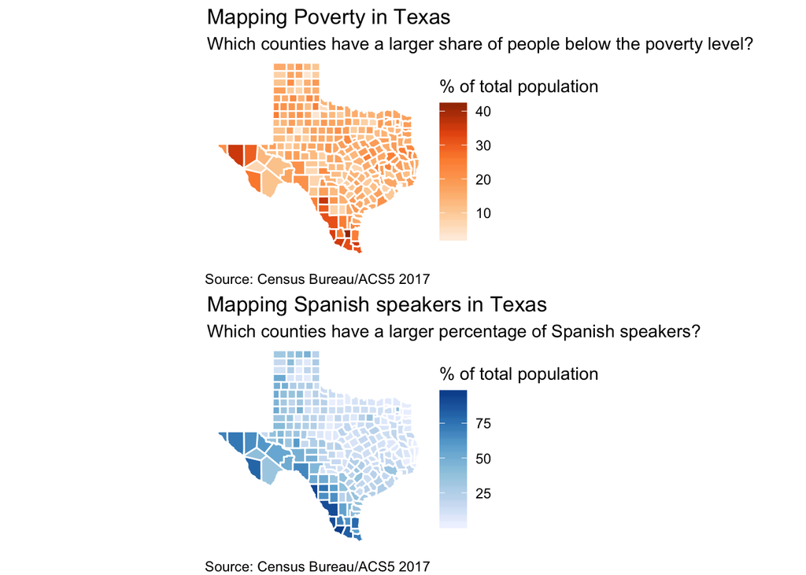

```r
spanish_map <- left_join(tx_map, spanish, by=c("AFFGEOID"="id"))

spanish_map %>% saveRDS("data-out/spanish_map.rds")


spanish_map_gg <- ggplot(spanish_map) +
  geom_sf(aes(fill=spanish_pct), color="white") +
  theme_void() +
  theme(panel.grid.major = element_line(colour = 'transparent')) +
  scale_fill_distiller(palette="Blues", direction=1, name="% of total population") +
  labs(title="Mapping Spanish speakers in Texas", subtitle = "Which counties have a larger percentage of Spanish speakers?", caption="Source: Census Bureau/ACS5 2017")

iron(poverty_map_gg, spanish_map_gg)
```

Both seem to have a higher percentage along the southern border

Sources update: Ask Norma Ortiz (ESL teacher in El Paso, teaches Spanish students) about her experience teaching Spanish speakers. Why do you think Spanish speakers acquire English language slower? Why do you want to teach ESL? How do you think your experience teaching ESL differs vs if you were to teach in another city like Austin/Dallas/Houston or non-border communities? How does a Spanish speaker’s English proficiency relate to their level of education?